# To be an SDE & plan schedule 27cc78862a3647c492c6fe4fcf114ce9

# To be an SDE & plan schedule

https://www.zhihu.com/question/582771512

https://symbol.iamkasong.com/docs/idea/introduce.html

https://web.mit.edu/6.102/www/sp23/

sde

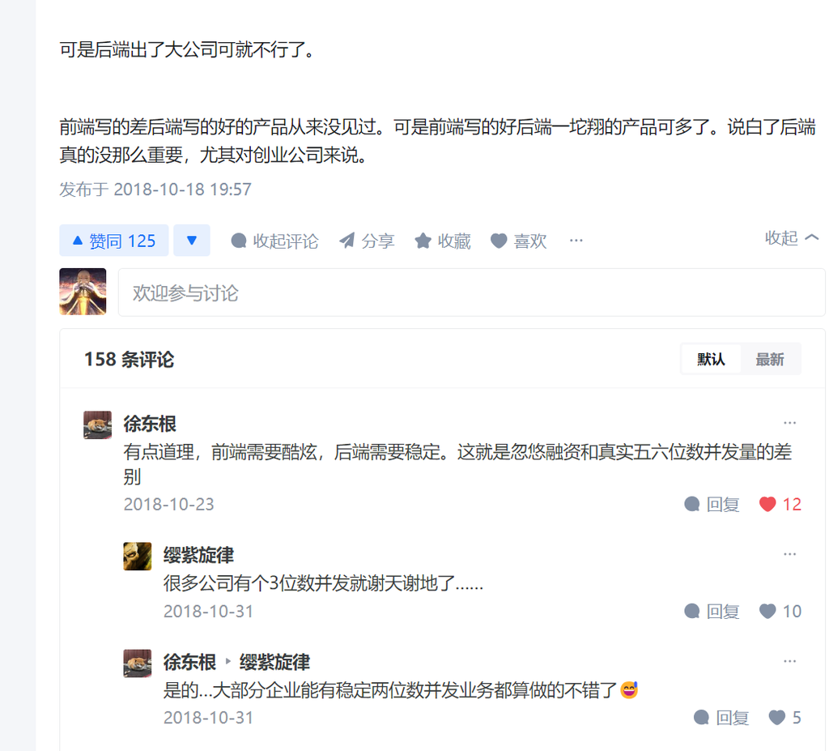

Untitled

[figure not shown]

Untitled

客户端 ⇒ 就是PC端

服务器： 电脑 接受更多的请求

# My work way && 项目管理

Trust the process

我不是现在才又开始迷茫了

我是一直就很迷茫，只不过一些事情摆在面前让我稍微遗忘了

被工作学习充满,但是没有想过自己是怎样的 提升自己一直很痛苦

原来的泰山之路突然没了绳索，就只能靠自己攀爬了

事情从来都是一件一件的完成的，长征从现在才开始 长征只是路途长罢了，但是我会去快乐的追求！

互联网上的太多美好容易让人迷失方向，产生幻觉。不要生活在虚拟的世界中。参加课外活动比参加网上交友好多了

厉害的人太多了 我不是其他人，我只是我 比较的对象只有我自己。

我想成为怎样的人呢 北美软件开发工程师 SDE 有趣可靠的伙伴 也是一个敢于表达自己，敢于争取机会的人

最后写给自己的话：想放纵，可以 必须完成一个不小的目标之后才可以放纵 不可以放纵，这是一个伪命题，放纵的时机自然会到来

菩萨心肠雷霆手段是最喜欢的八个字

专业能力该有哪些

该往哪个方向培养呢

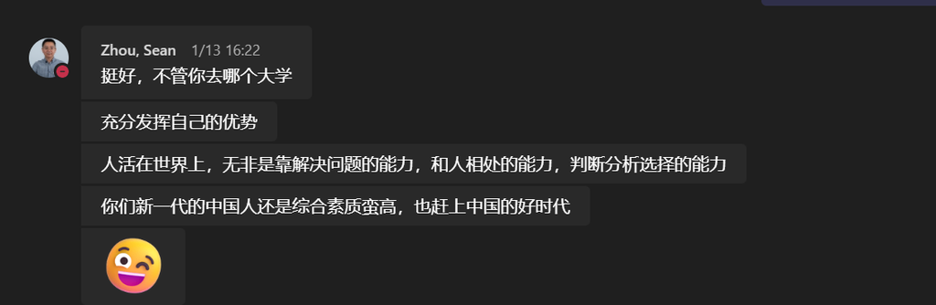

Untitled

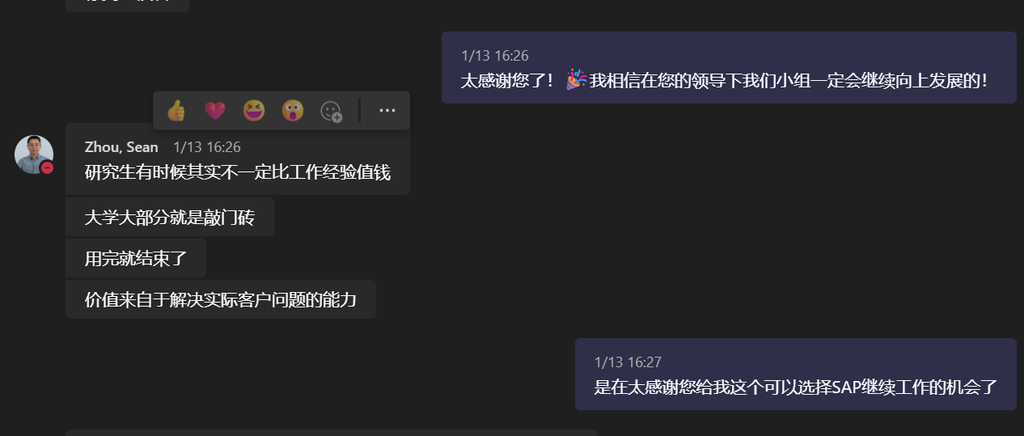

Untitled

生活应该如何管理&&项目应该如何管理

- Java 类型消除
- 懒加载的实现
- 闭包
- 泛型
- severless
- 前后端分离的paper

  https://juejin.cn/post/6844903655850639368?searchId=20231104031249E2EF936B9236EB1FEF5D

## 外网上的内容更多

stackoverflow

为什么后端框架没有前端那么多

# CS的资料

https://github.com/Developer-Y/cs-video-courses?tab=readme-ov-file#software-engineering

https://github.com/timqian/chinese-independent-blogs

# CS的发展

既然是编程语言了，语言，最重要的是讲了什么东西而不是语法了

那么就是内容最重要了

软件 = coding

*web开发已经到头了 只能当做 side project*

以后的方向，看有什么机会再选吧

嵌入式，硬件，no！

投递公司 ⇒ 选几家公司去 + 大厂

要去找人，而不是海投，简历要match 对着JD看 简历要思考具体的点

我能够给公司带来什么

我的过往学历可以证明我的 工作态度，学习习惯，学习效率是没问题的

一个研究生如果只干了本科生干的事情，那么就不如本科生

硬件的发展，1080p和4k8k的区别，经济好的时候大家可以上8k，经济不好的时候，不会买的

以后的发展：没有说我不能去做sales，什么都可以干，脑子灵活一点 engineering只能够糊口

高级工程师的面试：问到回答不出来为止 ⇒ 对于工程到底想了多少

nivida最强大的是生态而不是GPU

中国内卡住的是 生产而不是设计

📢 web开发就是高级的ppt

# CS

https://juejin.cn/post/7236278986257629221?searchId=202308031714145C3E0388D50A71640114

[『前端技术』相比后端是否只能打辅助? - 掘金](https://juejin.cn/post/6844903857156292621)

是的,在当前环境下这个说法无疑是成立的,可是我们忽略了一个基本情况,目前国内绝大部分企业都是面向 C 端企业,比如美团、滴滴、知乎、淘宝、百度、头条等等，能数得上的巨头企业无疑服务于 c 端用户，如果你业余对产品有一定研究就应该知道一个基本理念，c 端产品的设计必须越简单越好，c 端产品必须基于一个基本假设–用户都是傻子

举个例子,即使如今淘宝注册已经如此方便了，在 2017 年淘宝赞助的春晚当夜淘宝的客服炸了，原因不是服务器顶不住，而是下沉到三四线甚至县城的淘宝新用户疯狂打电话问淘宝客服如何绑定银行卡？

所以在这种产品设计理念下，前端根本不可能做出什么花样来，因为前端产品的复杂度永远不能超过 c 端用户理解能力的下限。

[前端科普系列（1）：前端简史 - 掘金](https://juejin.cn/post/6844904079202713608)

💡 业务前端不算CS

- **前端：** 针对浏览器的开发，代码在浏览器中运行
- **后端：** 针对服务器的开发，代码在服务器中运行

# 系统设计

这本书很重要

https://refactoringguru.cn/design-patterns/decorator

设计模式（Design Pattern）是前辈们对代码开发经验的总结，是解决特定问题的一系列套路。它不是语法规定，而是一套用来提高代码可复用性、可维护性、可读性、稳健性以及安全性的解决方案。

设计模式

https://zhuanlan.zhihu.com/p/128145128

https://www.zhihu.com/question/29477933/answer/3061179965

发布与订阅模式 ⇒ [https://vue3js.cn/interview/design/Observer Pattern.html#三、区别](https://vue3js.cn/interview/design/Observer%20%20Pattern.html#%E4%B8%89%E3%80%81%E5%8C%BA%E5%88%AB)

1. **发布订阅模式：** 在发布订阅模式中，消息的发送者（发布者）和消息的接收者（订阅者）之间存在松耦合关系。**发布者不直接向特定的订阅者发送消息，而是将消息发送到一个称为”主题”或”通道”的中介**，订阅者可以选择订阅感兴趣的主题，并在有新消息时接收通知。这种模式可以支持多个订阅者同时接收相同的消息，**也可以实现消息的广播和过滤**。
2. **观察者模式：** 在观察者模式中，存在一个被观察者（主题）和多个观察者（订阅者）之间的一对多关系。被观察者维护一个观察者列表，并在自身状态发生变化时通知所有的观察者。观察者模式强调被观察者和观察者之间的依赖关系，当被观察者的状态发生变化时，所有的观察者都会收到通知并进行相应的更新。

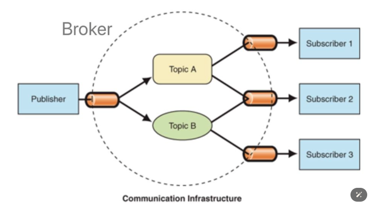

Untitled

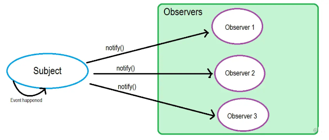

Untitled

和 jobTracker 还有 TaskTracker 还略微不同

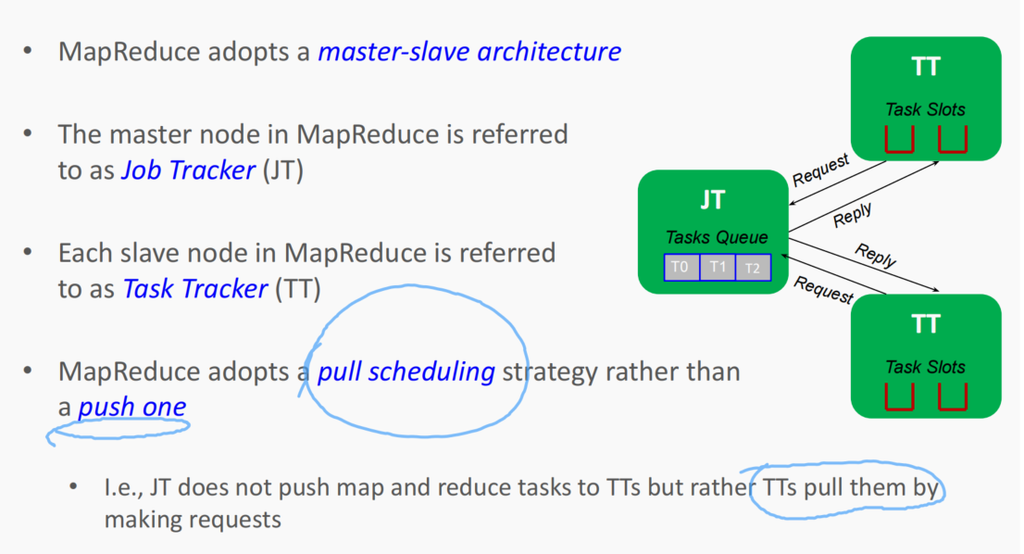

Untitled